# kaggle competation 1 final

### The dataset is proccessed before and columns that have unique values are taken in features to avoid the delay and memory usage for loading the dat to tain and test.

```python
import os
import json
import numpy as np
import pandas as pd
from pandas.io.json import json_normalize
import matplotlib.pyplot as plt
import seaborn as sns
import gc

from sklearn import model_selection, preprocessing, metrics

features = ['channelGrouping', 'date', 'fullVisitorId', 'visitId','visitNumber',
'visitStartTime', 'device.browser','device.deviceCategory',
'device.isMobile', 'device.operatingSystem','geoNetwork.city',
'geoNetwork.continent', 'geoNetwork.country',
'geoNetwork.metro', 'geoNetwork.networkDomain', 'geoNetwork.region',
'geoNetwork.subContinent', 'totals.bounces', 'totals.hits',
'totals.newVisits', 'totals.pageviews', 'totals.transactionRevenue',
'trafficSource.adContent', 'trafficSource.campaign',
'trafficSource.isTrueDirect', 'trafficSource.keyword',
'trafficSource.medium', 'trafficSource.referralPath',
'trafficSource.source']


def load_df(csv_path='../input/train.csv'):
    JSON_COLUMNS = ['device', 'geoNetwork', 'totals', 'trafficSource']
    load_dataframe = pd.DataFrame()
    reading_csvfile = pd.read_csv(csv_path, sep=',',
                     converters={column: json.loads for column in JSON_COLUMNS},
                     dtype={'fullVisitorId': 'str'},
                    chunksize = 100000)
    for df in reading_csvfile:
        df.reset_index(drop = True,inplace = True)
        for column in JSON_COLUMNS:
            column_as_df = json_normalize(df[column])
            column_as_df.columns = [f"{column}.{subcolumn}" for subcolumn in column_as_df.columns]
            df = df.drop(column, axis=1).merge(column_as_df, right_index=True, left_index=True)
        #here we create a dataframe and merge columns that is converted from JSON type
        print(f"Loaded {os.path.basename(csv_path)}. Shape: {df.shape}")
        dataframe_useful = df[features]
        del df  #delete df
        gc.collect()
        load_dataframe = pd.concat([load_dataframe, dataframe_useful], axis = 0).reset_index(drop = True)
        print(load_dataframe.shape)
    return load_dataframe
```

### Loading csv to dataframe

```python
test_df = load_df('D:/KAGGLE/test_v2/test_v2.csv')
```

```
Loaded test_v2.csv. Shape: (100000, 59)
(100000, 29)
Loaded test_v2.csv. Shape: (100000, 59)
(200000, 29)
Loaded test_v2.csv. Shape: (100000, 59)
(300000, 29)
Loaded test_v2.csv. Shape: (100000, 59)
(400000, 29)
Loaded test_v2.csv. Shape: (1589, 59)
(401589, 29)
```

```python
#test_df.head()
#df_train.head(500)
train_df = load_df('D:/KAGGLE/train_v2/train_v2.csv')
```

```
Loaded train_v2.csv. Shape: (100000, 59)
(100000, 29)
Loaded train_v2.csv. Shape: (100000, 60)
(200000, 29)
Loaded train_v2.csv. Shape: (100000, 59)
(300000, 29)
Loaded train_v2.csv. Shape: (100000, 59)
(400000, 29)
Loaded train_v2.csv. Shape: (100000, 59)
(500000, 29)
Loaded train_v2.csv. Shape: (100000, 59)
(600000, 29)
Loaded train_v2.csv. Shape: (100000, 59)
(700000, 29)
Loaded train_v2.csv. Shape: (100000, 59)
(800000, 29)
Loaded train_v2.csv. Shape: (100000, 59)
(900000, 29)
Loaded train_v2.csv. Shape: (100000, 59)
(1000000, 29)
Loaded train_v2.csv. Shape: (100000, 59)
(1100000, 29)
Loaded train_v2.csv. Shape: (100000, 59)
(1200000, 29)
Loaded train_v2.csv. Shape: (100000, 59)
(1300000, 29)
Loaded train_v2.csv. Shape: (100000, 59)
(1400000, 29)
Loaded train_v2.csv. Shape: (100000, 59)
(1500000, 29)
Loaded train_v2.csv. Shape: (100000, 59)
(1600000, 29)
Loaded train_v2.csv. Shape: (100000, 59)
(1700000, 29)
Loaded train_v2.csv. Shape: (8337, 59)
(1708337, 29)
```

```python
train_df.shape
train_df.head(5)
#list(df_train)
#gdf = test_df.groupby("fullVisitorId")["totals.transactionRevenue"]
#gdf.head()
```

|  | channelGrouping | date | fullVisitorId | visitId | visitNumber | visitStartTime | device.browser | device.deviceCategory | device.isMobile | device.operatingSystem | ... | totals.newVisits | totals.pageviews | totals.transactionRevenue | trafficSource.adContent | trafficSource.campaign | trafficSource.isTrueDirect | trafficSource.keyword | trafficSource.medium | trafficSource.referralPath | trafficSource.source |
| --- | --- | --- | --- | --- | --- | --- | --- | --- | --- | --- | --- | --- | --- | --- | --- | --- | --- | --- | --- | --- | --- |
| 0 | Organic Search | 20171016 | 3162355547410993243 | 1508198450 | 1 | 1508198450 | Firefox | desktop | False | Windows | ... | 1 | 1 | NaN | NaN | (not set) | NaN | water bottle | organic | NaN | google |
| 1 | Referral | 20171016 | 8934116514970143966 | 1508176307 | 6 | 1508176307 | Chrome | desktop | False | Chrome OS | ... | NaN | 2 | NaN | NaN | (not set) | NaN | NaN | referral | /a/google.com/transportation/mtv-services/bike... | sites.google.com |
| 2 | Direct | 20171016 | 7992466427990357681 | 1508201613 | 1 | 1508201613 | Chrome | mobile | True | Android | ... | 1 | 2 | NaN | NaN | (not set) | True | NaN | (none) | NaN | (direct) |
| 3 | Organic Search | 20171016 | 9075655783635761930 | 1508169851 | 1 | 1508169851 | Chrome | desktop | False | Windows | ... | 1 | 2 | NaN | NaN | (not set) | NaN | (not provided) | organic | NaN | google |
| 4 | Organic Search | 20171016 | 6960673291025684308 | 1508190552 | 1 | 1508190552 | Chrome | desktop | False | Windows | ... | 1 | 2 | NaN | NaN | (not set) | NaN | (not provided) | organic | NaN | google |

5 rows × 29 columns

#### Here train column has many object type so we need to convert to specific type

```python
train_df.info()
```

```
<class 'pandas.core.frame.DataFrame'>
RangeIndex: 1708337 entries, 0 to 1708336
Data columns (total 29 columns):
channelGrouping               object
date                          int64
fullVisitorId                 object
visitId                       int64
visitNumber                   int64
visitStartTime                int64
device.browser                object
device.deviceCategory         object
device.isMobile               bool
device.operatingSystem        object
geoNetwork.city               object
geoNetwork.continent          object
geoNetwork.country            object
geoNetwork.metro              object
geoNetwork.networkDomain      object
geoNetwork.region             object
geoNetwork.subContinent       object
totals.bounces                object
totals.hits                   object
totals.newVisits              object
totals.pageviews              object
totals.transactionRevenue     object
trafficSource.adContent       object
trafficSource.campaign        object
trafficSource.isTrueDirect    object
trafficSource.keyword         object
trafficSource.medium          object
trafficSource.referralPath    object
trafficSource.source          object
dtypes: bool(1), int64(4), object(24)
memory usage: 366.6+ MB
```

#### Convert rev from obj to float type

```python
train_df["totals.transactionRevenue"] = train_df["totals.transactionRevenue"].astype('float')
groupdf = train_df.groupby("fullVisitorId")["totals.transactionRevenue"].sum().reset_index()
```

```python
groupdf['totals.transactionRevenue'].unique().tolist()[:5]
```

```
[0.0, 33590000.0, 9490000.0, 79990000.0, 96350000.0]
```

#### Find unique customer who generate revenue

```python
nonzero_instance = pd.notnull(train_df["totals.transactionRevenue"]).sum()
nonzero_uniq = (groupdf["totals.transactionRevenue"]>0).sum()
print("Number of instances in train set with non-zero revenue : ", nonzero_instance, " and ratio is : ", nonzero_instance / train_df.shape[0])
print("Number of unique customers with revenue greater than 0. : ", nonzero_uniq, "and the ratio is : ", nonzero_uniq / groupdf.shape[0])
```

```
Number of instances in train set with non-zero revenue :  18514  and ratio is :  0.010837440153786987
Number of unique customers with revenue greater than 0. :  16141 and the ratio is :  0.012193574218307359
```

### Finding number of unique visitors in both train and test sets

```python
print("Number of unique visitors in train set : ",train_df.fullVisitorId.nunique(), " out of rows : ",train_df.shape[0])
print("Number of unique visitors in test set : ",test_df.fullVisitorId.nunique(), " out of rows : ",test_df.shape[0])
print("Number of common visitors in train and test set : ",len(set(train_df.fullVisitorId.unique()).intersection(set(test_df.fullVisitorId.unique())) ))
```

```
Number of unique visitors in train set :  1323730  out of rows :  1708337
Number of unique visitors in test set :  296530  out of rows :  401589
Number of common visitors in train and test set :  2759
```

### Function for finding the missing values in the columns of the dataframe and finding its percentage

```python
def missing_values(data):
    total = data.isnull().sum().sort_values(ascending = False)
    # getting the sum of null values and ordering i.e nan values
    percent = (data.isnull().sum() / data.isnull().count() * 100 ).sort_values(ascending = False)
    #getting the percent and order of null
    df = pd.concat([total, percent], axis=1, keys=['Total', 'Percent'])
    print("Total columns at least one Values: ")
    print (df[~(df['Total'] == 0)])
    # Returning values of nulls different of 0(i.e nan values) as total contains nan values here.
    print("\n Total of Sales % of Total: ", round((data['totals.transactionRevenue'].count() / len(data['totals.transactionRevenue']) * 100),4))
    #or we can use data[~np.isnan(data['totals.transactionRevenue'])] for getting non nan values

    return
```

#### Here we can see that transactionRevenue has 98.9% of null values...and hence the 80/20 rule has proven true for many businesses–only a small percentage of customers produce most of the revenue. As such, marketing teams are challenged to make appropriate investments in promotional strategies.

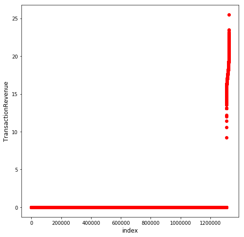

```python
plt.figure(figsize=(8,8))
plt.scatter(range(groupdf.shape[0]), np.sort(np.log1p(groupdf["totals.transactionRevenue"].values)),color='red')
plt.xlabel('index', fontsize=12)
plt.ylabel('TransactionRevenue', fontsize=12)
plt.show()
```

```python
missing_values(train_df)
```

```
Total columns at least one Values:
                              Total    Percent
totals.transactionRevenue   1689823  98.916256
trafficSource.adContent     1643600  96.210525
trafficSource.isTrueDirect  1173819  68.711209
trafficSource.referralPath  1142073  66.852910
trafficSource.keyword       1052780  61.626014
totals.bounces               836759  48.980910
totals.newVisits             400907  23.467676
totals.pageviews                239   0.013990

 Total of Sales % of Total:  1.0837
```

```python
#groupdf = train_df.groupby("fullVisitorId")["totals.transactionRevenue"].sum().reset_index()
non_rev_c = groupdf[groupdf['totals.transactionRevenue']==0]#has rev column that are 0
#rev_gen_c = groupdf[groupdf['totals.transactionRevenue']>0]#has rev column that are above 0
print("The number of nonrevenue customers are ", len(non_rev_c))
print("The number of revenue generating customers are ",nonzero_uniq)
print("the ratio of revenue generating customers are {0:0.4}%".format((nonzero_uniq)/len(groupdf)*100))
```

```
The number of nonrevenue customers are  1307589
The number of revenue generating customers are  16141
the ratio of revenue generating customers are 1.219%
```

##### Fill the missing nan with 0 in rev column

```python
train_df['totals.transactionRevenue'].fillna(0.0, inplace=True)
```

```python
nzr = train_df[train_df['totals.transactionRevenue']>0]['totals.transactionRevenue']
```

#### Use %matplotlib inline here to view the visualization here in notebook

- We can see that the total transaction rev in not normal distributed

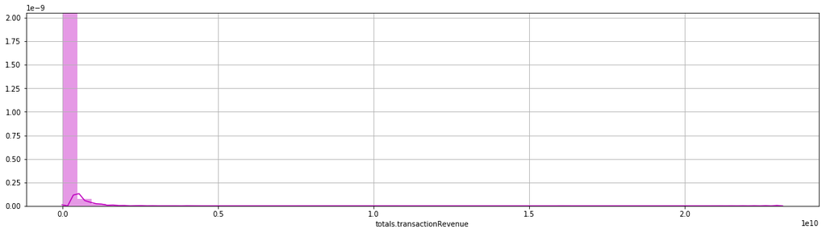

```python
%matplotlib inline
plt.subplots(figsize=(20,5))
plt.grid()
sns.distplot(nzr, color="m")
```

#### converting the rev column to log function and ploting

```python
log_revenue = train_df["totals.transactionRevenue"].apply(np.log1p)
```

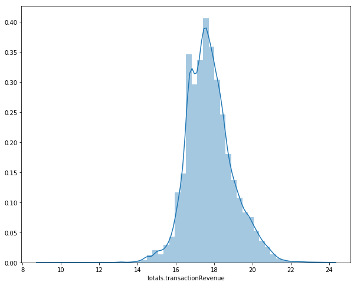

```python
plt.figure(figsize=(10,8))
nzr = log_revenue[log_revenue>0]
sns.distplot(nzr)
```

```python
train_df.head()
```

|  | channelGrouping | date | fullVisitorId | visitId | visitNumber | visitStartTime | device.browser | device.deviceCategory | device.isMobile | device.operatingSystem | ... | totals.newVisits | totals.pageviews | totals.transactionRevenue | trafficSource.adContent | trafficSource.campaign | trafficSource.isTrueDirect | trafficSource.keyword | trafficSource.medium | trafficSource.referralPath | trafficSource.source |
| --- | --- | --- | --- | --- | --- | --- | --- | --- | --- | --- | --- | --- | --- | --- | --- | --- | --- | --- | --- | --- | --- |
| 0 | Organic Search | 20171016 | 3162355547410993243 | 1508198450 | 1 | 1508198450 | Firefox | desktop | False | Windows | ... | 1 | 1 | 0.0 | NaN | (not set) | NaN | water bottle | organic | NaN | google |
| 1 | Referral | 20171016 | 8934116514970143966 | 1508176307 | 6 | 1508176307 | Chrome | desktop | False | Chrome OS | ... | NaN | 2 | 0.0 | NaN | (not set) | NaN | NaN | referral | /a/google.com/transportation/mtv-services/bike... | sites.google.com |
| 2 | Direct | 20171016 | 7992466427990357681 | 1508201613 | 1 | 1508201613 | Chrome | mobile | True | Android | ... | 1 | 2 | 0.0 | NaN | (not set) | True | NaN | (none) | NaN | (direct) |
| 3 | Organic Search | 20171016 | 9075655783635761930 | 1508169851 | 1 | 1508169851 | Chrome | desktop | False | Windows | ... | 1 | 2 | 0.0 | NaN | (not set) | NaN | (not provided) | organic | NaN | google |
| 4 | Organic Search | 20171016 | 6960673291025684308 | 1508190552 | 1 | 1508190552 | Chrome | desktop | False | Windows | ... | 1 | 2 | 0.0 | NaN | (not set) | NaN | (not provided) | organic | NaN | google |

5 rows × 29 columns

#### Extract the datetime format Using pandas

```python
from datetime import datetime
#To convert into to readable date format to explore the changes in the rev generation
def processing_date(df):
    df["date"] = pd.to_datetime(df["date"], format="%Y%m%d") # seting the column as pandas datetime
    df["weekday"] = df['date'].dt.weekday #extracting week day
    df["day"] = df['date'].dt.day # extracting day
    df["month"] = df['date'].dt.month # extracting day
    df["year"] = df['date'].dt.year # extracting day
    df['visitHour'] = (df['visitStartTime'].apply(lambda x: str(datetime.fromtimestamp(x).hour))).astype(int)

    return df
```

```python
train_df = processing_date(train_df)
test_df = processing_date(test_df)
```

```python
train_copy = train_df.copy()
test_copy = test_df.copy()
```

#### Exploring Date column in train data set

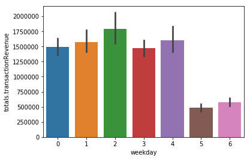

```python
sns.barplot(x=train_df['weekday'], y=train_df['totals.transactionRevenue'], data=train_df)
```

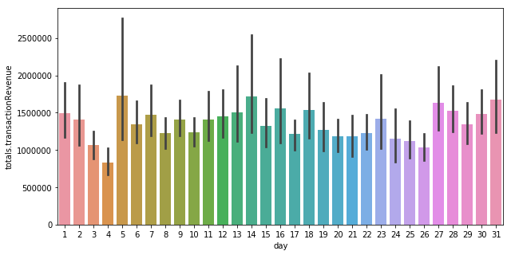

```python
%matplotlib inline
plt.figure(figsize=(10,5))
sns.barplot(x=train_df['day'], y=train_df['totals.transactionRevenue'] ,data=train_df)
```

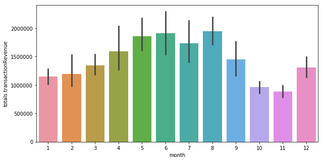

```python
plt.figure(figsize=(10,5))
sns.barplot(x=train_df['month'], y=train_df['totals.transactionRevenue'], data=train_df)
```

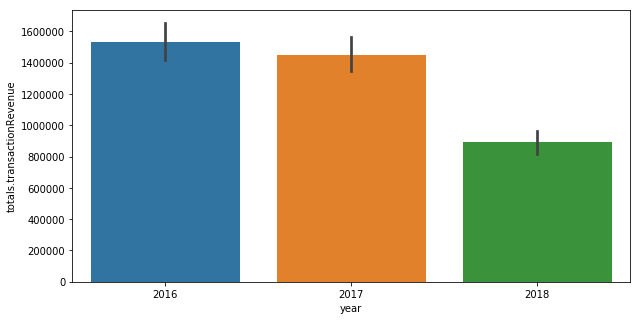

```python
plt.figure(figsize=(10,5))
sns.barplot(x=train_df['year'], y=train_df['totals.transactionRevenue'], data=train_df)
```

### From the above exploration we can make an inference that,

- During the starting and mid of the weekdays and mid of the year there is more revenue generation

```python
train_df['date'].describe()
```

```
count                 1708337
unique                    638
top       2017-12-12 00:00:00
freq                     9234
first     2016-08-01 00:00:00
last      2018-04-30 00:00:00
Name: date, dtype: object
```

```python
test_df['date'].describe()
```

```
count                  401589
unique                    168
top       2018-05-10 00:00:00
freq                     3884
first     2018-05-01 00:00:00
last      2018-10-15 00:00:00
Name: date, dtype: object
```

**We can see that train set has data from aug 1st 2016 to april 30th 2018**  
**Test set has data from may 1st 2018 to Oct 15th 2018**

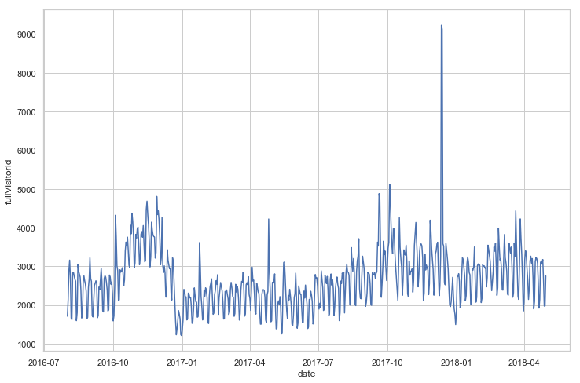

```python
cnt_srs = train_df.groupby('date')['fullVisitorId'].size().reset_index()
plt.figure(figsize=(12, 8))
sns.set(style="whitegrid")
sns.lineplot( cnt_srs['date'],cnt_srs['fullVisitorId'])
```

**- More customers have visited the store during nov to dec**

### using regular expression for extracting the sub column in data set to category_cols list

```python
import re
def extract_col(category):
    category_cols = list()
    for i in train_df.columns:
        a = re.findall(r'^'+category+'.*',i)
        if a:
            category_cols.append(a[0])
        else:
            continue
    return category_cols
```

```python
def category_plots(col,height,width):
    sample = train_df.loc[:,[col, 'totals.transactionRevenue']]
    sample['totals.transactionRevenue'] = sample['totals.transactionRevenue'].replace(0.0, np.nan)
    cnt_srs = sample.groupby(col)['totals.transactionRevenue'].agg(['size','count','mean'])
    cnt_srs.columns = ["count", 'count of non-zero revenue', "mean transaction value"]
    cnt_srs = cnt_srs.sort_values(by="count", ascending=False)
    print(cnt_srs.head(10))
    plt.figure(figsize=(height, width))
    plt.subplot(3,1,1)
    sns.barplot(x=cnt_srs['count'].head(10), y=cnt_srs.index[:10])
    plt.subplot(3,1,2)
    sns.barplot(x=cnt_srs['count of non-zero revenue'].head(10), y=cnt_srs.index[:10])
    plt.subplot(3,1,3)
    sns.barplot(x=cnt_srs['mean transaction value'].head(10), y=cnt_srs.index[:10])
#extact device,traffic columns
device_cols = extract_col('device')

traffic_cols = extract_col('trafficSource')
train_df[traffic_cols].nunique(dropna=False)
```

```
trafficSource.adContent         77
trafficSource.campaign          33
trafficSource.isTrueDirect       2
trafficSource.keyword         4547
trafficSource.medium             7
trafficSource.referralPath    3197
trafficSource.source           345
dtype: int64
```

```python
device_cols
```

```
['device.browser',
 'device.deviceCategory',
 'device.isMobile',
 'device.operatingSystem']
```

```
                         count  count of non-zero revenue  \
device.operatingSystem
Windows                 619720                       3571
Macintosh               438514                      10354
Android                 299386                        753
iOS                     219334                        832
Linux                    63971                       1300
Chrome OS                51318                       1703
(not set)                11815                          0
Windows Phone             1675                          1
Samsung                    911                          0
Tizen                      709                          0

                        mean transaction value
device.operatingSystem
Windows                           1.610381e+08
Macintosh                         1.270264e+08
Android                           6.670659e+07
iOS                               4.312514e+07
Linux                             5.404468e+07
Chrome OS                         1.583395e+08
(not set)                                  NaN
Windows Phone                     2.640000e+07
Samsung                                    NaN
Tizen                                      NaN
```

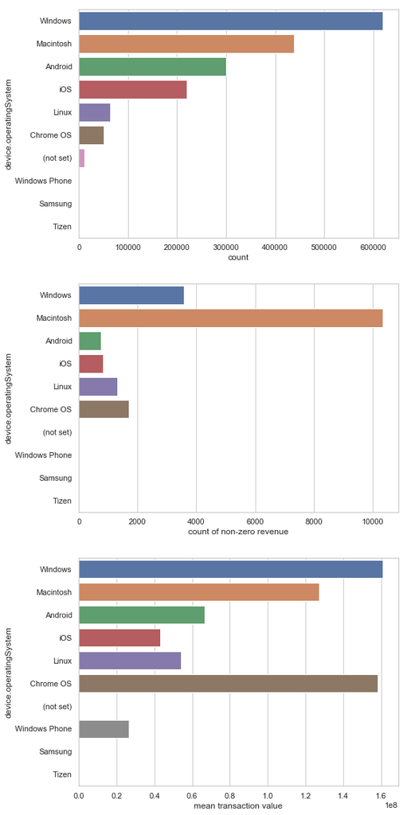

```python
category_plots('device.operatingSystem',8,20)
```

**Inference**

```
                         count  count of non-zero revenue  \
device.deviceCategory
desktop                1171579                      16905
mobile                  471336                       1364
tablet                   65422                        245

                       mean transaction value
device.deviceCategory
desktop                          1.318602e+08
mobile                           5.447116e+07
tablet                           5.285339e+07
```

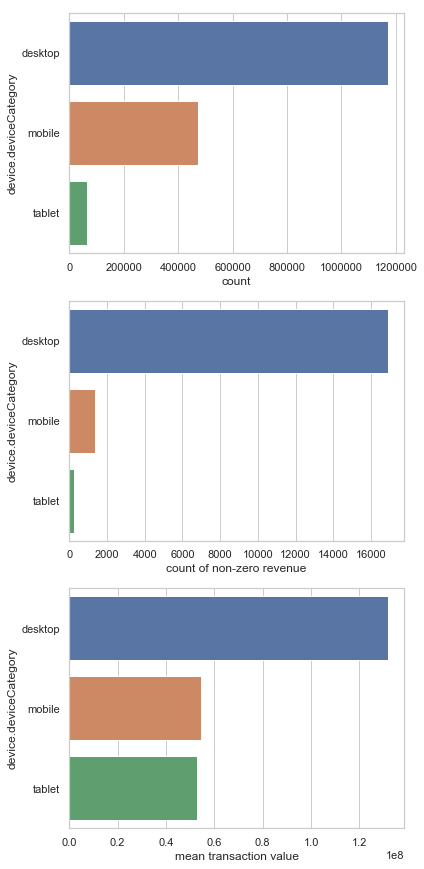

```python
category_plots('device.deviceCategory',6,15)
```

**Inference**

> - Desktop users as well as the revenue generated from them is more compared to others.

```
                     count  count of non-zero revenue  mean transaction value
device.browser
Chrome             1173056                      16697            1.238645e+08
Safari              312165                       1210            6.338925e+07
Firefox              63845                        339            4.432043e+08
Internet Explorer    35474                        148            8.079703e+07
Android Webview      34266                         10            1.861100e+07
Edge                 20543                         74            1.090176e+08
Samsung Internet     15792                          8            2.760625e+07
Opera Mini           15018                          0                     NaN
Safari (in-app)      14207                         12            1.281417e+07
Opera                 9585                         14            4.248357e+07
```

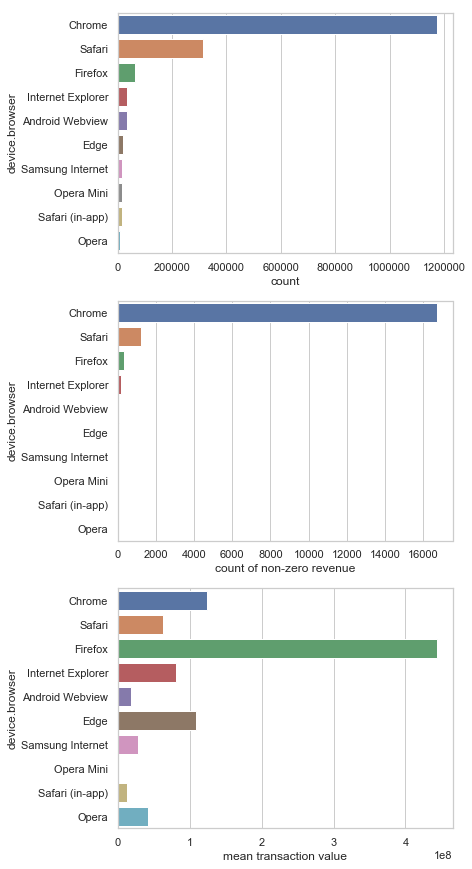

```python
category_plots('device.browser',6,15)
```

**Inference**

##### Exploring traffic Source category

```python
traffic_cols = extract_col('trafficSource')
```

```python
traffic_cols
```

```
['trafficSource.adContent',
 'trafficSource.campaign',
 'trafficSource.isTrueDirect',
 'trafficSource.keyword',
 'trafficSource.medium',
 'trafficSource.referralPath',
 'trafficSource.source']
```

```
                                count  count of non-zero revenue  \
trafficSource.adContent
Google Merchandise Store        39566                          5
Google Merchandise Collection    6762                        152
Placement Accessores 300 x 250   3040                          5
Smart display ad - 8/17/2017     2664                          0
Display Ad created 3/11/14       2344                          9
Google Online Store              1773                          6
Official Google Merchandise       866                         25
Ad from 12/15/17                  853                          0
Full auto ad IMAGE ONLY           822                          5
Placement Drinkware 300x250       653                          0

                                mean transaction value
trafficSource.adContent
Google Merchandise Store                  2.510200e+07
Google Merchandise Collection             1.358018e+08
Placement Accessores 300 x 250            1.154380e+08
Smart display ad - 8/17/2017                       NaN
Display Ad created 3/11/14                6.330222e+07
Google Online Store                       3.516333e+07
Official Google Merchandise               6.877880e+07
Ad from 12/15/17                                   NaN
Full auto ad IMAGE ONLY                   5.247600e+07
Placement Drinkware 300x250                        NaN
```

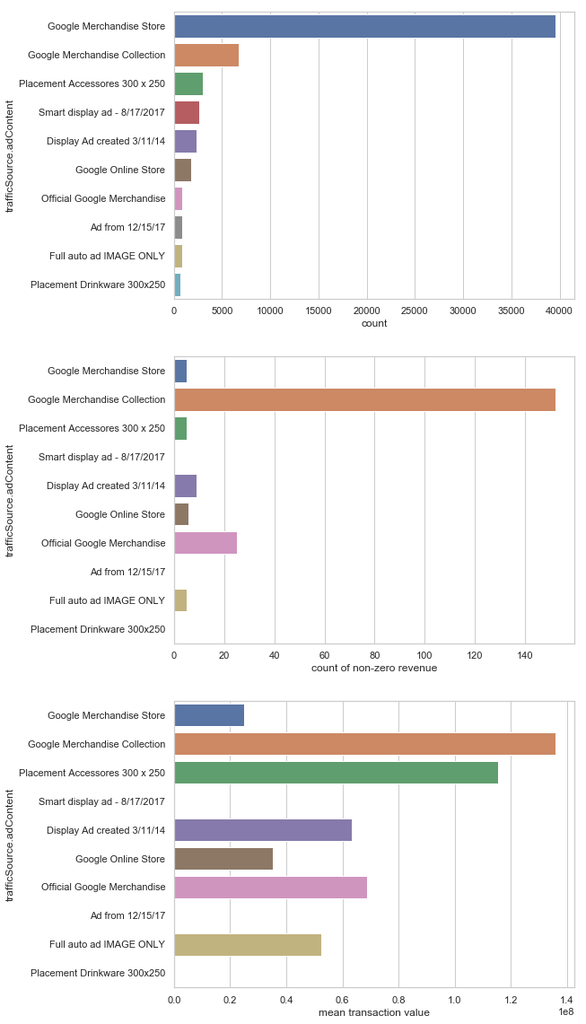

```python
category_plots('trafficSource.adContent',8,20)
```

**Inference**

```
                       count  count of non-zero revenue  \
trafficSource.source
google                658384                       4683
(direct)              565975                      13144
youtube.com           329450                         25
analytics.google.com   37436                          3
Partners               32931                         17
sites.google.com        9072                         76
google.com              8341                         14
m.facebook.com          6737                          7
dfa                     6704                        137
baidu                   4971                          0

                      mean transaction value
trafficSource.source
google                          1.001894e+08
(direct)                        1.282169e+08
youtube.com                     2.337640e+07
analytics.google.com            7.823333e+06
Partners                        5.088647e+07
sites.google.com                9.024539e+07
google.com                      5.175500e+07
m.facebook.com                  2.825571e+07
dfa                             7.353030e+08
baidu                                    NaN
```

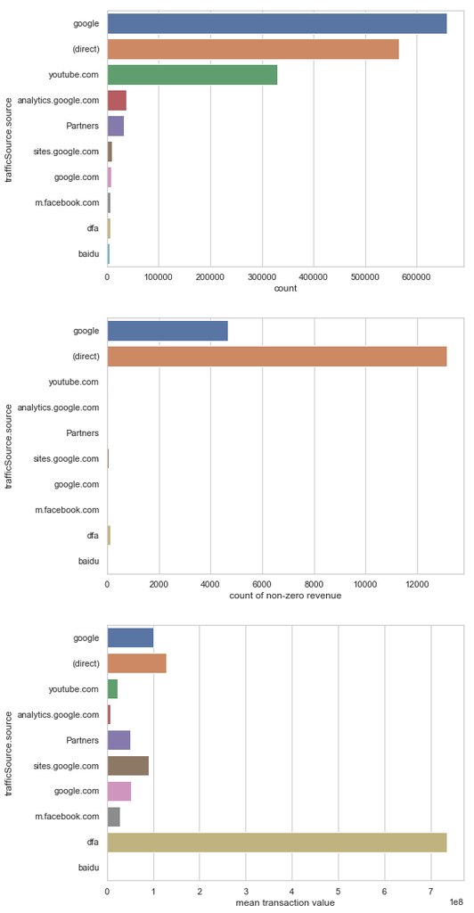

```python
category_plots('trafficSource.source',8,20)
```

**Inference**

> - From this source column we see that google and through direct source more rev is generated

```python
Geonetwork_clos = extract_col('geoNetwork')
```

```python
train_df[Geonetwork_clos].nunique(dropna=False)
```

```
geoNetwork.city               956
geoNetwork.continent            6
geoNetwork.country            228
geoNetwork.metro              123
geoNetwork.networkDomain    41982
geoNetwork.region             483
geoNetwork.subContinent        23
dtype: int64
```

#### let us do EDA with geoNetwork.country,geoNetwork.networkDomain,geoNetwork.continent

```
                           count  count of non-zero revenue  \
geoNetwork.networkDomain
(not set)                 499049                      10867
unknown.unknown           269796                        665
comcast.net                55486                       1505
rr.com                     28715                        588
verizon.net                26547                        755
ttnet.com.tr               17078                          1
comcastbusiness.net        16826                        454
hinet.net                  15933                         17
virginm.net                12594                          1
cox.net                    10722                        236

                          mean transaction value
geoNetwork.networkDomain
(not set)                           1.201659e+08
unknown.unknown                     8.759997e+07
comcast.net                         1.178171e+08
rr.com                              9.052170e+07
verizon.net                         1.055277e+08
ttnet.com.tr                        1.746000e+07
comcastbusiness.net                 4.581096e+08
hinet.net                           5.497824e+07
virginm.net                         6.227000e+07
cox.net                             1.210655e+08
```

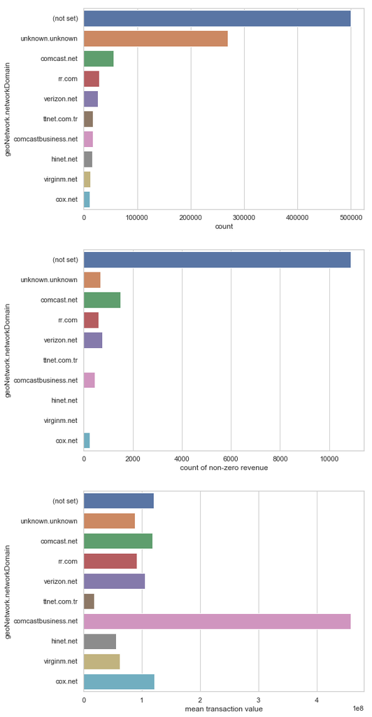

```python
category_plots('geoNetwork.networkDomain',8,20)
```

```
                       count  count of non-zero revenue  \
geoNetwork.continent
Americas              877403                      18150
Asia                  396719                        190
Europe                368037                        126
Africa                 35481                         12
Oceania                28180                         29
(not set)               2517                          7

                      mean transaction value
geoNetwork.continent
Americas                        1.247988e+08
Asia                            1.231459e+08
Europe                          8.926548e+07
Africa                          7.521658e+08
Oceania                         2.338310e+08
(not set)                       1.136029e+08
```

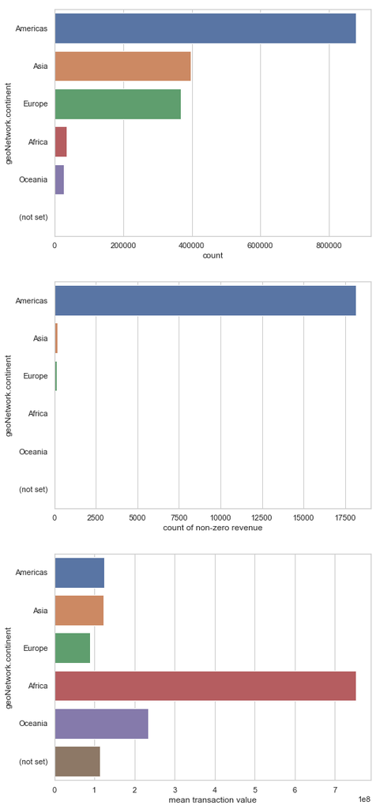

```python
category_plots('geoNetwork.continent',8,20)
```

**Inference**

> - Americans contribute mojority reveue Here from the above visualisation.

```
                     count  count of non-zero revenue  mean transaction value
geoNetwork.country
United States       717217                      17658            1.244697e+08
India               105317                         18            7.425056e+07
United Kingdom       73341                         25            9.900160e+07
Canada               51057                        315            1.355531e+08
Germany              38516                         12            6.402000e+07
Japan                36637                         22            3.346136e+08
Brazil               35432                         21            9.631952e+07
Vietnam              34869                          0                     NaN
France               32289                         11            9.733545e+07
Thailand             29859                         10            6.141600e+07
```

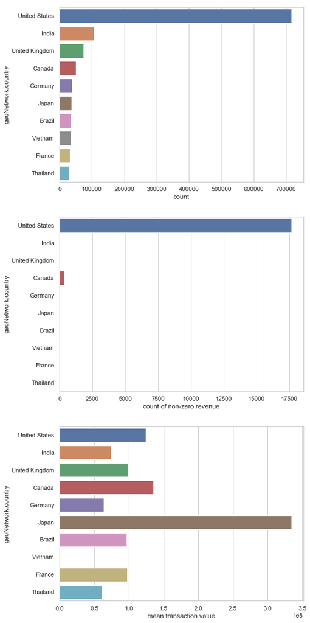

```python
category_plots('geoNetwork.country',8,20)
```

```python
len(train_df)
```

```
1708337
```

```python
def total_col_plots(col):
    a = train_df.loc[:,[col, 'totals.transactionRevenue']]
    a['totals.transactionRevenue'] = a['totals.transactionRevenue'].replace(0.0, np.nan)
    cnt_srs = a.groupby(col)['totals.transactionRevenue'].agg(['size','count','mean'])
    cnt_srs.columns = ["count", 'count of non-zero revenue', "mean"]
    cnt_srs['total_revenue'] = cnt_srs['count of non-zero revenue']*cnt_srs['mean']
    cnt_srs = cnt_srs.sort_values(by="count", ascending=False)
    print(cnt_srs.head(10))
    plt.figure(figsize=(15, 20))
    plt.subplot(4,1,1)
    sns.barplot(y=cnt_srs['count'].head(50), x=list(range(1,51)))
    plt.subplot(4,1,2)
    sns.barplot(y=cnt_srs['count of non-zero revenue'].head(50), x=list(range(1,51)))
    plt.subplot(4,1,3)
    sns.barplot(y=cnt_srs['mean'].head(50), x=list(range(1,51)))
    plt.subplot(4,1,4)
    sns.barplot(y=cnt_srs['total_revenue'].head(50), x=list(range(1,51)))
```

```python
train_df.dtypes
```

```
channelGrouping                       object
date                          datetime64[ns]
fullVisitorId                         object
visitId                                int64
visitNumber                            int64
visitStartTime                         int64
device.browser                        object
device.deviceCategory                 object
device.isMobile                         bool
device.operatingSystem                object
geoNetwork.city                       object
geoNetwork.continent                  object
geoNetwork.country                    object
geoNetwork.metro                      object
geoNetwork.networkDomain              object
geoNetwork.region                     object
geoNetwork.subContinent               object
totals.bounces                        object
totals.hits                           object
totals.newVisits                      object
totals.pageviews                      object
totals.transactionRevenue            float64
trafficSource.adContent               object
trafficSource.campaign                object
trafficSource.isTrueDirect            object
trafficSource.keyword                 object
trafficSource.medium                  object
trafficSource.referralPath            object
trafficSource.source                  object
weekday                                int64
day                                    int64
month                                  int64
year                                   int64
visitHour                              int32
dtype: object
```

**creating categorical_cols**

```python
categorical_cols = list()
for i in train_df.columns:
    if train_df[i].dtype=='object' and (not(i.startswith('total'))):
        categorical_cols.append(i)
```

```python
len(categorical_cols)

train_df[categorical_cols].nunique(dropna=False)
#here we are removing the fullvistorId as it is int type
categorical_cols.remove('fullVisitorId')
#we are appending the bool column of is mobile to categorical_cols
categorical_cols.append('device.isMobile')
```

```python
#creating the numerical column apart fromt he obj and bool type
numerical_cols = list()
for i in train_df.columns:
    if train_df[i].dtype not in ['object', 'bool']:
        numerical_cols.append(i)
numerical_cols
```

```
['date',
 'visitId',
 'visitNumber',
 'visitStartTime',
 'totals.transactionRevenue',
 'weekday',
 'day',
 'month',
 'year',
 'visitHour']
```

```python
#As date, visitId,visitStartTime,year are not necessary for analysis
#so remove it.
numerical_cols.remove('date')
numerical_cols.remove('visitId')
numerical_cols.remove('visitStartTime')
numerical_cols.remove('year')
numerical_cols
```

```
['visitNumber',
 'totals.transactionRevenue',
 'weekday',
 'day',
 'month',
 'visitHour']
```

```python
#list the columns that are not there in the numerical_cols + categorical_cols
#upon which we apply the algorithm for prediction
set(train_df.columns)-set(numerical_cols + categorical_cols)
```

```
{'date',
 'fullVisitorId',
 'totals.bounces',
 'totals.hits',
 'totals.newVisits',
 'totals.pageviews',
 'visitId',
 'visitStartTime',
 'year'}
```

```python
#these columns were not there in numerical but are neccesary for analysis
numerical_cols.append('totals.bounces')
numerical_cols.append('totals.hits')
numerical_cols.append('totals.newVisits')
numerical_cols.append('totals.pageviews')
numerical_cols
```

```
['visitNumber',
 'totals.transactionRevenue',
 'weekday',
 'day',
 'month',
 'visitHour',
 'totals.bounces',
 'totals.hits',
 'totals.newVisits',
 'totals.pageviews']
```

```python
train_df[numerical_cols].isnull().sum()
```

```
visitNumber                       0
totals.transactionRevenue         0
weekday                           0
day                               0
month                             0
visitHour                         0
totals.bounces               836759
totals.hits                       0
totals.newVisits             400907
totals.pageviews                239
dtype: int64
```

**Filling the nan values with specific data for eveluation**

```python
#fill the nan values with 0 for train and test sets
train_df['totals.bounces'] = train_df['totals.bounces'].fillna(0)
test_df['totals.bounces'] = test_df['totals.bounces'].fillna(0)

train_df['totals.newVisits'] = train_df['totals.newVisits'].fillna(0)
test_df['totals.newVisits'] = test_df['totals.newVisits'].fillna(0)

# since null value of pageviews yields no revenue, we will fillit with 0
train_df['totals.pageviews'] = train_df['totals.pageviews'].fillna(1)
test_df['totals.pageviews'] = test_df['totals.pageviews'].fillna(1)
train_df[numerical_cols].info()
```

```
<class 'pandas.core.frame.DataFrame'>
RangeIndex: 1708337 entries, 0 to 1708336
Data columns (total 10 columns):
visitNumber                  int64
totals.transactionRevenue    float64
weekday                      int64
day                          int64
month                        int64
visitHour                    int32
totals.bounces               object
totals.hits                  object
totals.newVisits             object
totals.pageviews             object
dtypes: float64(1), int32(1), int64(4), object(4)
memory usage: 123.8+ MB
```

```python
#convert from the string type to the int type in both test and train sets
for col in ['totals.bounces', 'totals.hits', 'totals.newVisits','totals.pageviews' ]:
    train_df[col] = train_df[col].astype(int)
    test_df[col] = test_df[col].astype(int)
train_df[numerical_cols].info()
```

```
<class 'pandas.core.frame.DataFrame'>
RangeIndex: 1708337 entries, 0 to 1708336
Data columns (total 10 columns):
visitNumber                  int64
totals.transactionRevenue    float64
weekday                      int64
day                          int64
month                        int64
visitHour                    int32
totals.bounces               int32
totals.hits                  int32
totals.newVisits             int32
totals.pageviews             int32
dtypes: float64(1), int32(5), int64(4)
memory usage: 97.8 MB
```

```python
cat_null = train_df[categorical_cols].isnull().sum()
cat_null_percent= cat_null/len(train_df)*100
cat_null_percent
```

```
channelGrouping                0.000000
device.browser                 0.000000
device.deviceCategory          0.000000
device.operatingSystem         0.000000
geoNetwork.city                0.000000
geoNetwork.continent           0.000000
geoNetwork.country             0.000000
geoNetwork.metro               0.000000
geoNetwork.networkDomain       0.000000
geoNetwork.region              0.000000
geoNetwork.subContinent        0.000000
trafficSource.adContent       96.210525
trafficSource.campaign         0.000000
trafficSource.isTrueDirect    68.711209
trafficSource.keyword         61.626014
trafficSource.medium           0.000000
trafficSource.referralPath    66.852910
trafficSource.source           0.000000
device.isMobile                0.000000
dtype: float64
```

```python
#here we fill bool column for nan with false and reflecting in the original dataset
train_df['trafficSource.isTrueDirect'].fillna(False, inplace=True)
test_df['trafficSource.isTrueDirect'].fillna(False, inplace=True)
train_df.isnull().sum()
#counting the number of null values in train dataframe
```

```
channelGrouping                     0
date                                0
fullVisitorId                       0
visitId                             0
visitNumber                         0
visitStartTime                      0
device.browser                      0
device.deviceCategory               0
device.isMobile                     0
device.operatingSystem              0
geoNetwork.city                     0
geoNetwork.continent                0
geoNetwork.country                  0
geoNetwork.metro                    0
geoNetwork.networkDomain            0
geoNetwork.region                   0
geoNetwork.subContinent             0
totals.bounces                      0
totals.hits                         0
totals.newVisits                    0
totals.pageviews                    0
totals.transactionRevenue           0
trafficSource.adContent       1643600
trafficSource.campaign              0
trafficSource.isTrueDirect          0
trafficSource.keyword         1052780
trafficSource.medium                0
trafficSource.referralPath    1142073
trafficSource.source                0
weekday                             0
day                                 0
month                               0
year                                0
visitHour                           0
dtype: int64
```

```python
#fill nan with unknown value for better model prediction.
for col in ['trafficSource.keyword',
            'trafficSource.referralPath',
            'trafficSource.adContent']:
    train_df[col].fillna('unknown', inplace=True)
    test_df[col].fillna('unknown', inplace=True)
train_df.shape
```

```
(1708337, 34)
```

```python
test_df.shape
```

```
(401589, 34)
```

```python
train_df.shape
```

```
(1708337, 34)
```

```python
train_new = train_df.copy()
test_new = test_df.copy()
```

**Before performing label encoding, we merge the test and train sets to insure we have consistent labels in the two sets:**

```python
from sklearn.preprocessing import LabelEncoder
for col in categorical_cols:
    print("transform column {}".format(col))
    lbe = LabelEncoder()
    lbe.fit(pd.concat([train_new[col],test_new[col]]).astype("str"))
    train_new[col] = lbe.transform(train_new[col].astype("str"))
    test_new[col] = lbe.transform(test_new[col].astype("str"))
```

```
transform column channelGrouping
transform column device.browser
transform column device.deviceCategory
transform column device.operatingSystem
transform column geoNetwork.city
transform column geoNetwork.continent
transform column geoNetwork.country
transform column geoNetwork.metro
transform column geoNetwork.networkDomain
transform column geoNetwork.region
transform column geoNetwork.subContinent
transform column trafficSource.adContent
transform column trafficSource.campaign
transform column trafficSource.isTrueDirect
transform column trafficSource.keyword
transform column trafficSource.medium
transform column trafficSource.referralPath
transform column trafficSource.source
transform column device.isMobile
```

```python
train_new.head()
```

|  | channelGrouping | date | fullVisitorId | visitId | visitNumber | visitStartTime | device.browser | device.deviceCategory | device.isMobile | device.operatingSystem | ... | trafficSource.isTrueDirect | trafficSource.keyword | trafficSource.medium | trafficSource.referralPath | trafficSource.source | weekday | day | month | year | visitHour |
| --- | --- | --- | --- | --- | --- | --- | --- | --- | --- | --- | --- | --- | --- | --- | --- | --- | --- | --- | --- | --- | --- |
| 0 | 4 | 2017-10-16 | 3162355547410993243 | 1508198450 | 1 | 1508198450 | 64 | 0 | 0 | 22 | ... | 0 | 3761 | 5 | 3757 | 117 | 0 | 16 | 10 | 2017 | 5 |
| 1 | 6 | 2017-10-16 | 8934116514970143966 | 1508176307 | 6 | 1508176307 | 55 | 0 | 0 | 3 | ... | 0 | 3709 | 6 | 339 | 339 | 0 | 16 | 10 | 2017 | 23 |
| 2 | 2 | 2017-10-16 | 7992466427990357681 | 1508201613 | 1 | 1508201613 | 55 | 1 | 1 | 1 | ... | 1 | 3709 | 0 | 3757 | 0 | 0 | 16 | 10 | 2017 | 6 |
| 3 | 4 | 2017-10-16 | 9075655783635761930 | 1508169851 | 1 | 1508169851 | 55 | 0 | 0 | 22 | ... | 0 | 8 | 5 | 3757 | 117 | 0 | 16 | 10 | 2017 | 21 |
| 4 | 4 | 2017-10-16 | 6960673291025684308 | 1508190552 | 1 | 1508190552 | 55 | 0 | 0 | 22 | ... | 0 | 8 | 5 | 3757 | 117 | 0 | 16 | 10 | 2017 | 3 |

5 rows × 34 columns

```python
test_new.head()
```

|  | channelGrouping | date | fullVisitorId | visitId | visitNumber | visitStartTime | device.browser | device.deviceCategory | device.isMobile | device.operatingSystem | ... | trafficSource.isTrueDirect | trafficSource.keyword | trafficSource.medium | trafficSource.referralPath | trafficSource.source | weekday | day | month | year | visitHour |
| --- | --- | --- | --- | --- | --- | --- | --- | --- | --- | --- | --- | --- | --- | --- | --- | --- | --- | --- | --- | --- | --- |
| 0 | 4 | 2018-05-11 | 7460955084541987166 | 1526099341 | 2 | 1526099341 | 55 | 1 | 1 | 1 | ... | 1 | 8 | 5 | 0 | 117 | 4 | 11 | 5 | 2018 | 9 |
| 1 | 2 | 2018-05-11 | 460252456180441002 | 1526064483 | 166 | 1526064483 | 55 | 0 | 0 | 7 | ... | 1 | 9 | 0 | 0 | 0 | 4 | 11 | 5 | 2018 | 0 |
| 2 | 4 | 2018-05-11 | 3461808543879602873 | 1526067157 | 2 | 1526067157 | 55 | 0 | 0 | 3 | ... | 1 | 8 | 5 | 0 | 117 | 4 | 11 | 5 | 2018 | 1 |
| 3 | 2 | 2018-05-11 | 975129477712150630 | 1526107551 | 4 | 1526107551 | 55 | 1 | 1 | 25 | ... | 1 | 9 | 0 | 0 | 0 | 4 | 11 | 5 | 2018 | 12 |
| 4 | 4 | 2018-05-11 | 8381672768065729990 | 1526060254 | 1 | 1526060254 | 71 | 2 | 1 | 22 | ... | 0 | 8 | 5 | 0 | 117 | 4 | 11 | 5 | 2018 | 23 |

5 rows × 34 columns

```python
numerical_cols.remove('totals.transactionRevenue')
```

```python
numerical_cols
```

```
['visitNumber',
 'weekday',
 'day',
 'month',
 'visitHour',
 'totals.bounces',
 'totals.hits',
 'totals.newVisits',
 'totals.pageviews']
```

**Here test_x has the features for predicting the test_y values.**

```python
train_X = train_new[categorical_cols+numerical_cols]
train_Y = train_new['totals.transactionRevenue']
```

```python
test_X = test_new[categorical_cols+numerical_cols]
test_Y = test_new['totals.transactionRevenue']
```

```python
test_X.head()
```

|  | channelGrouping | device.browser | device.deviceCategory | device.operatingSystem | geoNetwork.city | geoNetwork.continent | geoNetwork.country | geoNetwork.metro | geoNetwork.networkDomain | geoNetwork.region | ... | device.isMobile | visitNumber | weekday | day | month | visitHour | totals.bounces | totals.hits | totals.newVisits | totals.pageviews |
| --- | --- | --- | --- | --- | --- | --- | --- | --- | --- | --- | --- | --- | --- | --- | --- | --- | --- | --- | --- | --- | --- |
| 0 | 4 | 55 | 1 | 1 | 1 | 3 | 93 | 0 | 44691 | 126 | ... | 1 | 2 | 4 | 11 | 5 | 9 | 0 | 4 | 0 | 3 |
| 1 | 2 | 55 | 0 | 7 | 858 | 2 | 219 | 104 | 0 | 74 | ... | 0 | 166 | 4 | 11 | 5 | 0 | 0 | 4 | 0 | 3 |
| 2 | 4 | 55 | 0 | 3 | 1096 | 2 | 219 | 129 | 31310 | 517 | ... | 0 | 2 | 4 | 11 | 5 | 1 | 0 | 4 | 0 | 3 |
| 3 | 2 | 55 | 1 | 25 | 417 | 2 | 219 | 48 | 0 | 462 | ... | 1 | 4 | 4 | 11 | 5 | 12 | 0 | 5 | 0 | 4 |
| 4 | 4 | 71 | 2 | 22 | 432 | 2 | 219 | 64 | 8820 | 74 | ... | 1 | 1 | 4 | 11 | 5 | 23 | 0 | 5 | 1 | 4 |

5 rows × 28 columns

```python
train_Y = train_Y.apply(np.log1p)
```

```python
test_Y.unique()
```

```
array([nan, '21990000', '149990000', ..., '103920000', '206810000',
       '52320000'], dtype=object)
```

```python
train_new['date'].describe()
```

```
count                 1708337
unique                    638
top       2017-12-12 00:00:00
freq                     9234
first     2016-08-01 00:00:00
last      2018-04-30 00:00:00
Name: date, dtype: object
```

**Here we take the data above 2018-3-30 for checking validation**

```python
from datetime import date

val_df = train_new[train_new['date']>='2018-3-30']
val_X = val_df[categorical_cols+numerical_cols]
val_Y = val_df['totals.transactionRevenue']
```

```python
dev_df = train_new[train_new['date']<'2018-3-30']
train_X = dev_df[categorical_cols+numerical_cols]
train_Y = dev_df['totals.transactionRevenue']
```

```python
train_Y = train_Y.apply(np.log1p)
val_Y = val_Y.apply(np.log1p)
val_X.head()
```

|  | channelGrouping | device.browser | device.deviceCategory | device.operatingSystem | geoNetwork.city | geoNetwork.continent | geoNetwork.country | geoNetwork.metro | geoNetwork.networkDomain | geoNetwork.region | ... | device.isMobile | visitNumber | weekday | day | month | visitHour | totals.bounces | totals.hits | totals.newVisits | totals.pageviews |
| --- | --- | --- | --- | --- | --- | --- | --- | --- | --- | --- | --- | --- | --- | --- | --- | --- | --- | --- | --- | --- | --- |
| 17047 | 4 | 55 | 0 | 22 | 858 | 2 | 219 | 104 | 8906 | 74 | ... | 0 | 7 | 6 | 15 | 4 | 3 | 0 | 3 | 0 | 3 |
| 17048 | 2 | 64 | 0 | 22 | 1096 | 2 | 219 | 129 | 38476 | 517 | ... | 0 | 1 | 6 | 15 | 4 | 1 | 0 | 3 | 1 | 3 |
| 17049 | 1 | 102 | 1 | 25 | 536 | 2 | 219 | 64 | 36819 | 74 | ... | 1 | 1 | 6 | 15 | 4 | 2 | 0 | 3 | 1 | 3 |
| 17050 | 3 | 55 | 1 | 1 | 1096 | 3 | 93 | 129 | 44691 | 517 | ... | 1 | 3 | 6 | 15 | 4 | 5 | 0 | 3 | 0 | 3 |
| 17051 | 2 | 55 | 0 | 22 | 601 | 3 | 102 | 52 | 0 | 470 | ... | 0 | 1 | 6 | 15 | 4 | 10 | 0 | 3 | 1 | 3 |

5 rows × 28 columns

```python
# custom function to run light gbm model
import lightgbm as lgb
params = {
        "objective" : "regression",
        "boosting_type" : 'dart',
        "metric" : "rmse",
        "num_leaves" : 30,
        "min_child_samples" : 100,
        "learning_rate" : 0.05,
        "bagging_fraction" : 0.7,
        "feature_fraction" : 0.5,
        "bagging_frequency" : 5,
        "bagging_seed" : 2018,
        "verbosity" : 100
    }

lgtrain = lgb.Dataset(train_X, label=train_Y,categorical_feature=categorical_cols)
lgvalid = lgb.Dataset(val_X, label=val_Y,categorical_feature=categorical_cols)
lgbmodel = lgb.train(params, lgtrain, 2000, valid_sets=[lgvalid], early_stopping_rounds=100, verbose_eval=100)
```

```
Training until validation scores don't improve for 100 rounds.
[100]	valid_0's rmse: 1.37984
[200]	valid_0's rmse: 1.37146
[300]	valid_0's rmse: 1.36936
[400]	valid_0's rmse: 1.37057
Early stopping, best iteration is:
[340]	valid_0's rmse: 1.36839
```

```python
pred_test = lgbmodel.predict(test_X, num_iteration=lgbmodel.best_iteration)
pred_val = lgbmodel.predict(val_X, num_iteration=lgbmodel.best_iteration)
```

**Now let us compute the evaluation metric on the validation data. So we need to do a sum for all the transactions of the user and then do a log transformation on top. And make the values less than 0 to 0 as transaction revenue can only be 0 or more.**

```python
from sklearn import metrics
pred_val[pred_val<0] = 0
val_pred_df = pd.DataFrame({"fullVisitorId":val_df["fullVisitorId"].values})
val_pred_df["transactionRevenue"] = val_df["totals.transactionRevenue"].values
val_pred_df["PredictedRevenue"] = np.expm1(pred_val)
#print(np.sqrt(metrics.mean_squared_error(np.log1p(val_pred_df["transactionRevenue"].values), np.log1p(val_pred_df["PredictedRevenue"].values))))
val_pred_df = val_pred_df.groupby("fullVisitorId")["transactionRevenue", "PredictedRevenue"].sum().reset_index()
print(np.sqrt(metrics.mean_squared_error(np.log1p(val_pred_df["transactionRevenue"].values), np.log1p(val_pred_df["PredictedRevenue"].values))))
'''1.4855904993409212 1.4494322142023286 1.4456313062463275'''
```

```
1.4423024928840236
```

```
'1.4855904993409212 1.4494322142023286 1.4456313062463275'
```

```python
test_id = test_df['fullVisitorId']
```

**Creating a submission file**

```python
sub_df = pd.DataFrame({"fullVisitorId":test_id})
pred_test[pred_test<0] = 0
sub_df["PredictedLogRevenue"] = np.expm1(pred_test)
sub_df = sub_df.groupby("fullVisitorId")["PredictedLogRevenue"].sum().reset_index()
sub_df.columns = ["fullVisitorId", "PredictedLogRevenue"]
sub_df["PredictedLogRevenue"] = np.log1p(sub_df["PredictedLogRevenue"])
sub_df.to_csv("D:\\Sub_file.csv", index=False)
```

```python
sub_df.shape
```

```
(296530, 2)
```